# Should we postpone our July 2020 wedding?

Isabelle Feldhaus, Antoine Lizée

2020-05-03

With the World Health Organization’s declaration of the Covid-19 pandemic in March 2020, the looming question has been whether or not to postpone our July wedding. A difficult decision before us, we wanted to take a quick look at the numbers to give some confidence to our decision, while keeping in mind that there are two key dimensions to consider: (1) health and (2) geopolitics.

To be clear, we’re not modeling or projecting anything here. We only wanted to look at the data ourselves since we couldn’t find our questions answered out there[^1]. Since we figured that we’re not the only nerds on this email list, we stitched the graphs together for your entertainment.

We used data collated by the [New York Times](https://github.com/nytimes/covid-19-data/raw/master/us-states.csv) (yes, NYT appears to be the cleanest and most complete data source at the moment) and the [European CDC](https://opendata.ecdc.europa.eu/covid19/casedistribution/csv) from mid-February to May 3rd to get a picture of Covid-19 trajectories in the United States and selected European countries, respectively. We computed the cumulative cases and deaths over the course of the pandemic, incidence (cases per day), and mortality (deaths per day) and adjusted for population size for each state or country.

Let’s take a look.

### The (Not So) United States

Indeed, there have been a lot of deaths in recent weeks…

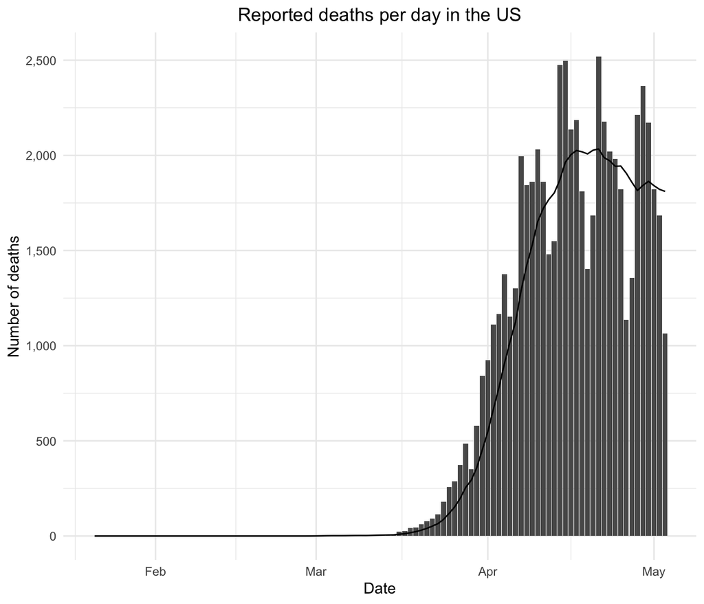

This graph shows the number of deaths per day in the US. For comparison, at its peak, Covid-19 caused more than **2,000** fatalities per day when in normal times, we’d expect about **7,700** deaths each day on average. That’s over 25%!

Note the dips in the graph. These are weekends and, subsequently, pauses in data collection. Because of these idiosyncracies in reporting, all the following figures show values for the past 7 days.

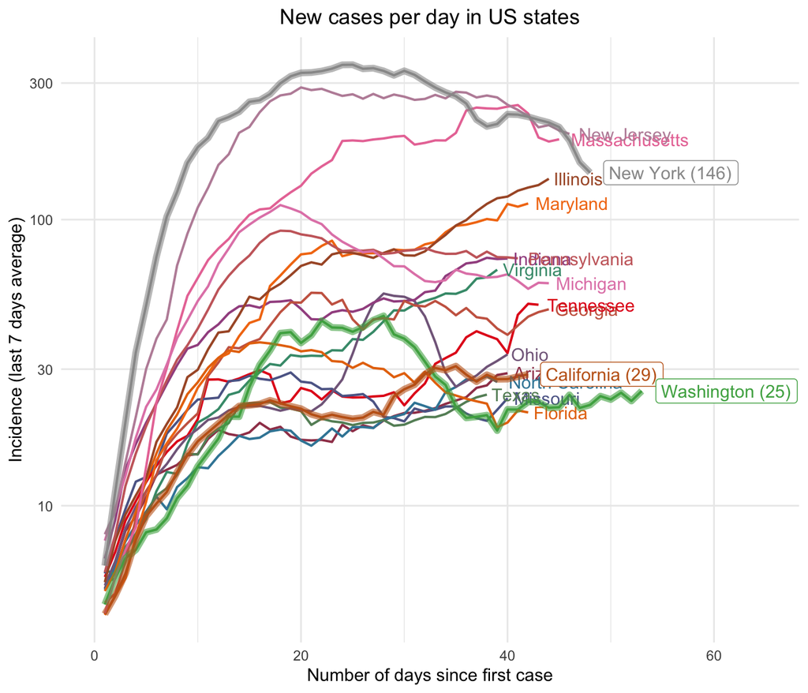

So, this graph is a *mess*. But we see a few interesting trends.

New York and New Jersey are moving together. Massachusetts is coming to get them. All that is unsurprising given their geographical proximity and interconnections.

We also see plateauing. We can surmise that this mirrors the stay-home orders in various states. Good examples are Washington, New York, and Michigan (good luck finding this one).

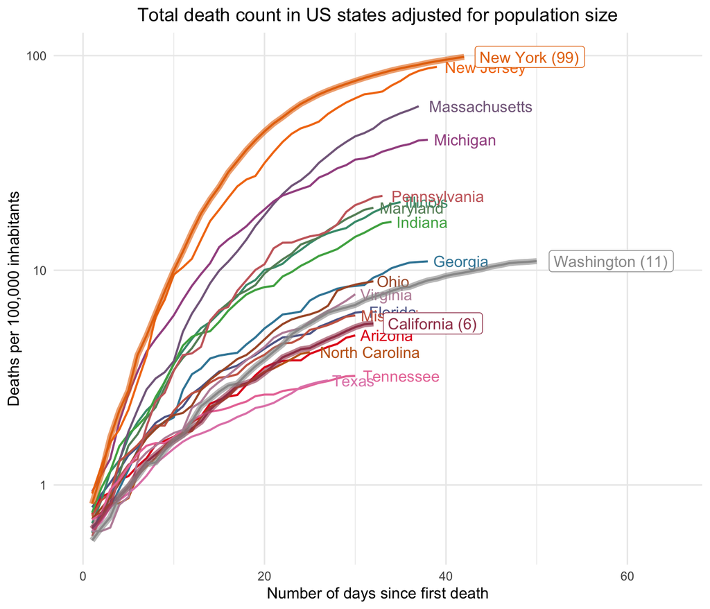

Looking at cases alone is not enough: case reporting is highly variable depending on testing protocols and resources.

Here, we look at total deaths since the beginning of the pandemic. The story is the same for New York, New Jersey, and Massachusetts - with Michigan actively *distancing* (ha) from them. Pennsylvania, Illinois, Indiana, and Maryland make a motley crew walking the middle path, while the rest seem to be following Washington’s trajectory. This “rest” is seeing roughly 10 times fewer deaths per inhabitants than the “top” states.

### What about Europe?

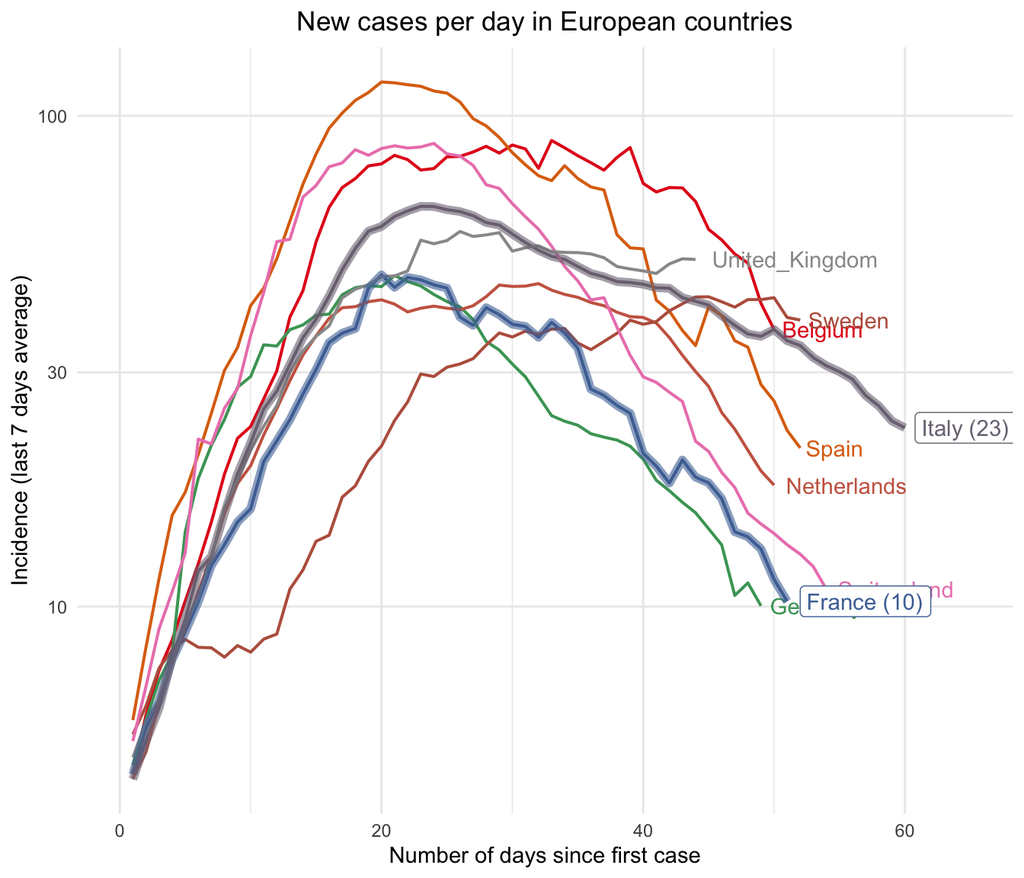

It’s easier to tell. They’re all roughly behaving the same, apart from Sweden and the UK. The Covid-19 slowdown potentially induced by lockdowns is much more pronounced as shown by the sharp decrease in new cases over the last 20 days.

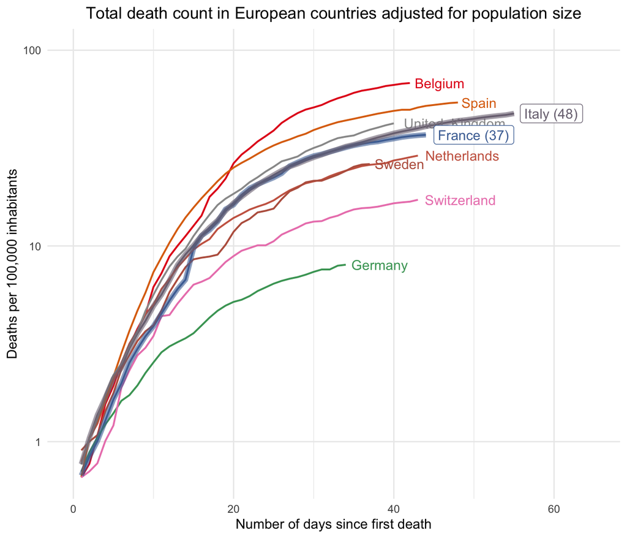

Adjusting for population shows that all of the countries are roughly hanging out in the same ballpark with the exception of Germany, who either has a magic trick or is reporting deaths differently.

Interestingly, we can see that France initially followed in the footsteps of Italy but has recently curbed deaths and will likely end up with fewer. This might be a result of having started a strong lockdown earlier in their trajectory.

### And now, what we’ve all been waiting for…Europe vs. US

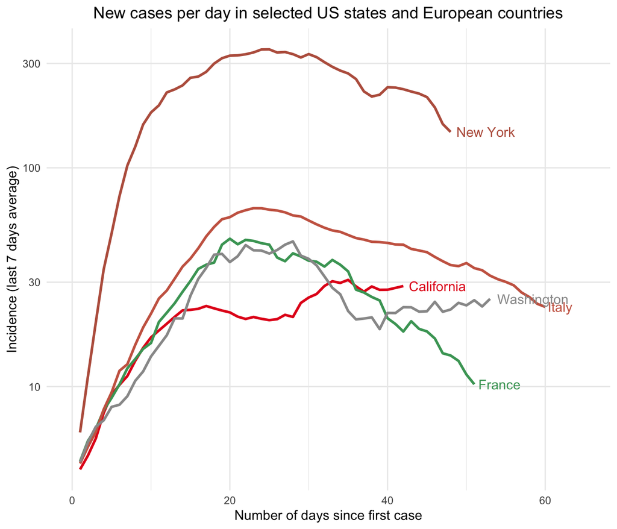

New York got hit later than European countries, but hard and fast. It’s astounding. We can see that it’s struggling to rein in the virus as fast as its US & European counterparts.

California and Washington appear to be hanging out in a plateau, while Italy and France seem to have decidedly reduced the activity of the disease.

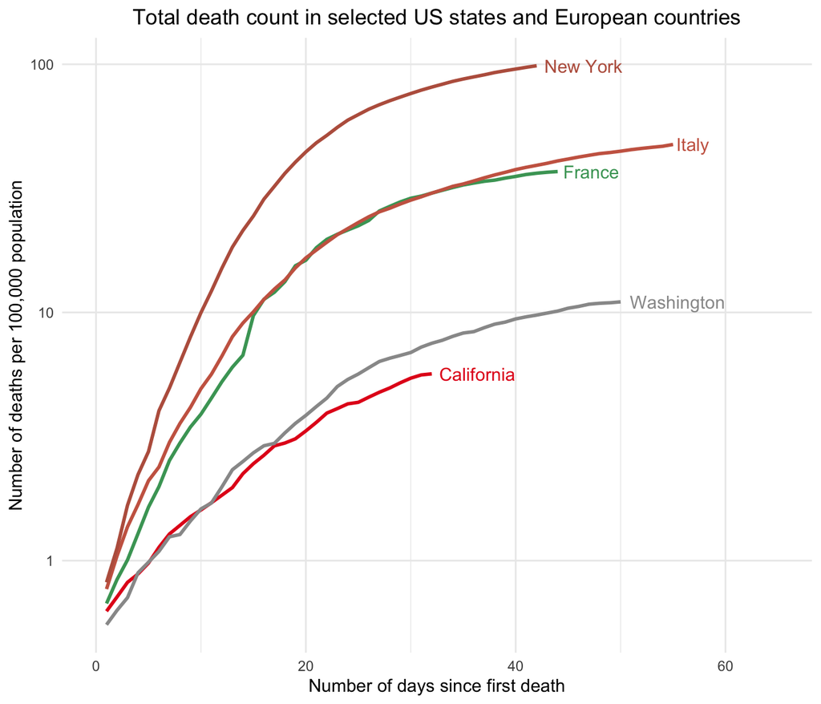

Dynamics across states are similar overall, with California being hit surprisingly late in the game. However, their adjusted total death counts are significantly different: France and Italy lie almost exactly between the worst-hit (New York) and best-behaving (California and Washington) states in the US.

We see that France and Italy report a higher level of mortality compared to California and Washington, but similar case counts. This illustrates differences in measuring & reporting of Covid-19 cases and deaths.

### So what?

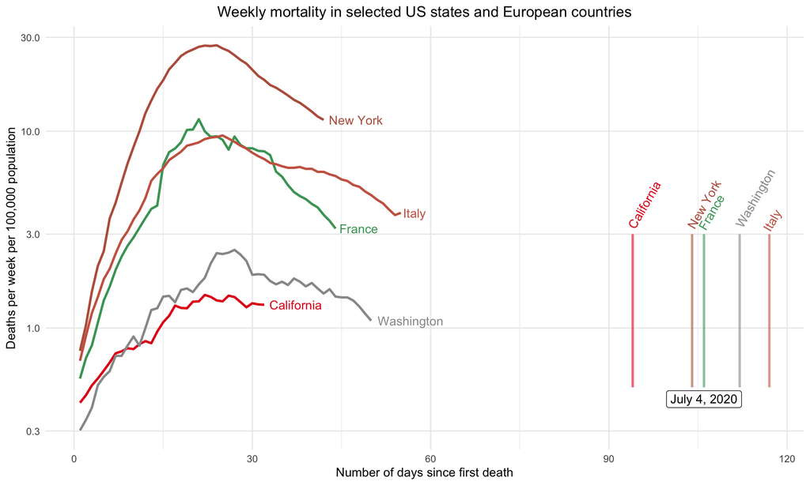

Based on the downward trends that we see and assuming that there is no strong rebound, there is some hope that, on the 4th of July, the health threat of Covid-19 will have greatly diminished.

On top of the uncertainty of the disease[^2], there is the uncertainty of international travel, border restrictions, and political context. The probability of Covid-19 being under control on July 4th is high, but the probability that we don’t have the legal right to party is quite high too. All in all, we couldn’t gamble with our guests’ nerves nor risk a last-minute cancellation[^3].

In truth, we made the decision to postpone our wedding two weeks ago. As you can see, this was when we most of the states were continuing the climb to the top. Of course, we still believe postponement to be the right decision.[^4] Over these past couple of weeks, amidst our search for the sword that seals the darkness[^5], we have confirmed the changes with each of our vendors and made arrangements for the 14th of July 2021.

**We can’t wait to laugh and dance with all of you beautiful humans!**

#### Update - May 10

If you’re here after May 5th, and you’re interested in how those trends have changed, here are [all of the updated graphs](https://raw.githack.com/antoine-lizee/covid/master/graph_updates.html).

Also, we’re delighted to see that the [Financial Times](https://ig.ft.com/coronavirus-chart/?areas=usa&areas=gbr&cumulative=0&logScale=1&perMillion=1&values=deaths) picked up our analysis[^6] and published it the same day as we did in a much nicer format. We encourage you to check it out if you’re curious!

[^1]: This is also our coping mechanism.
[^2]: Antoine wanted to spend at least another 10 hours analyzing this. Isabelle would not allow it.
[^3]: Two months before is not last-minute, right?
[^4]: Not to mention that we just found out that the *mairie* (i.e. city hall) will not be allowing weddings until mid-July as of today.
[^5]: This is a hint :)
[^6]: Fake news :-) But we’re happy to see that their pretty graphs match ours.